# BitPhylogeny: A probabilistic framework for reconstructing intra-tumor phylogenies

# 1 Installation

The `BitPhylogeny` packages depends on several `python` and `R` packages. The first step is to make sure the following the packages are installed. * `python`: numpy, scipy, scikit-learn: http://scikit-learn.org/stable/, rpy2: http://rpy.sourceforge.net/ * `R`: rPython, mcclust, e1071, igraph, gplots, riverplot

Secondly, clone the BitPhylogeny repository

```
git clone git@bitbucket.org:ke_yuan/bitphylogeny.git
cd bitphylogeny
```

The third step is install the BitPhylogeny python package. To do this, navigate into the python directory and run the following

```
cd python
sudo python setup.py install
```

Finally, install the R package

```
cd ../R
R CMD INSTALL bitphylogenyR_0.1.tar.gz
```

# 2 An example

## 2.1 BitPhylogeny

We use an example dataset

```r
library('bitphylogenyR')
example_file = system.file('sample_data.csv', package='bitphylogenyR')
tmp <- read.csv( example_file )
head(tmp)
```

```
##   V1 V2 V3 V4 V5 V6 V7 V8 V9
## 1  0  0  0  0  0  0  0  0  1
## 2  0  0  0  0  0  0  0  0  1
## 3  0  0  0  0  0  0  0  0  1
## 4  0  0  0  0  0  0  0  0  1
## 5  0  0  0  0  0  0  0  0  1
## 6  0  0  0  0  0  0  0  0  1
```

Note that the last column is set to be the true cluster label of each data point. We separate the data and its label.

```r
x <- tmp[,-dim(tmp)[2]]
true_label <- tmp[,dim(tmp)[2]]
```

Run the BitPhylogeny analysis as the following

```r
bitphyloR( example_file, './output', T, 20, 10, 2)
```

The program saves the results in the directory ‘output’.

```r
dir('./output', recursive=T)
```

```
##  [1] "sample_data.csv/mcmc-traces/branch_traces.csv"
##  [2] "sample_data.csv/mcmc-traces/label_traces.csv"
##  [3] "sample_data.csv/mcmc-traces/node_depth_traces.csv"
##  [4] "sample_data.csv/mcmc-traces/other_traces.csv"
##  [5] "sample_data.csv/mcmc-traces/params_traces/array_0.npz"
##  [6] "sample_data.csv/mcmc-traces/params_traces/array_1.npz"
##  [7] "sample_data.csv/mcmc-traces/params_traces/array_2.npz"
##  [8] "sample_data.csv/mcmc-traces/params_traces/array_3.npz"
##  [9] "sample_data.csv/mcmc-traces/params_traces/array_4.npz"
## [10] "sample_data.csv/mcmc-traces/params_traces/array_5.npz"
## [11] "sample_data.csv/mcmc-traces/params_traces/array_6.npz"
## [12] "sample_data.csv/mcmc-traces/params_traces/array_7.npz"
## [13] "sample_data.csv/mcmc-traces/params_traces/array_8.npz"
## [14] "sample_data.csv/mcmc-traces/params_traces/array_9.npz"
## [15] "sample_data.csv/treescripts/nodes-2.gdl"
## [16] "sample_data.csv/treescripts/nodes-3.gdl"
## [17] "sample_data.csv/treescripts/tree-freq.csv"
```

The clustering performance is assessed by the V-measure. In addition, the label trace is summarised by the maximum posterior expected adjusted Rand method.

```r
compute_vmeasures('./output/sample_data.csv',
                  system.file('sample_data.csv', package='bitphylogenyR'))
```

We can visualise the results in the following way

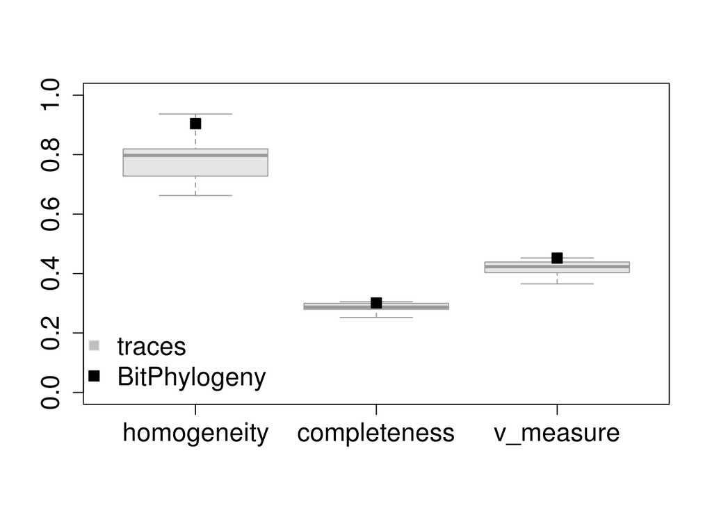

```r
fp <- get_path('./output/sample_data.csv', 'mcmc-traces')
vmeasure_traces <- as.matrix(load_vmeasures(fp, 'vmeasure_traces.csv'))
mpear_vmeasure <- as.matrix(load_vmeasures(fp, 'mpear_label_vmeasure.csv'))
class(vmeasure_traces) <- 'numeric'
class(mpear_vmeasure) <- 'numeric'
par(cex.lab=1.5, cex.axis=1.5)
boxplot(vmeasure_traces, outline=F, cex.main=1.3, ylim=c(0,1),
        border=c('gray60'), col='gray90')
points(c(1,2,3),mpear_vmeasure, pch=22,cex = 1.5, bg= 'black')
colors1 <- c("gray90",'black')
colors2 <- c("gray",'black')
add_legend("bottomleft", legend=c("traces", 'BitPhylogeny'),
           pch=c(22,22), inset = c(0.1,0.20), col=colors1,
           pt.bg=colors2,
           horiz=F, bty='n', cex=1.5)
```

The resulting trees are stored in the `treescripts` directory. The file `tree-freq` contains the appearance frequency of each tree in the folder.

```r
treefreq <- read.csv('./output/sample_data.csv/treescripts//tree-freq.csv')
treefreq
```

```
##   unique_node_num                freq
## 1               3 0.80000000000000004
## 2               2 0.20000000000000001
```

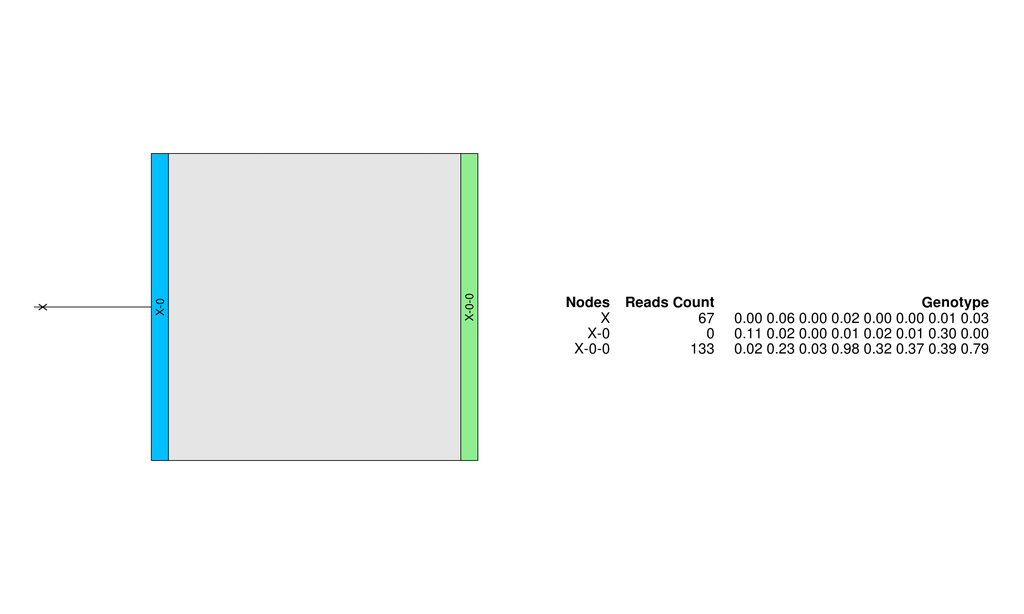

```r
plot_sankey_mft('./output/sample_data.csv/treescripts//tree-freq.csv')
```

Alternatively, the .gdl files can be visualised with the [aisee3](http://www.absint.com/aisee/index.htm) software.

## 2.2 Baseline methods

The baseline methods are consisted of clustering followed by minimum spanning tree construction.

### 2.2.1 Hierarchical clustering

We first compute the Jacard distance matrix for the sequences.

```r
dis <- dist(x, 'binary')
```

Then, we use the R function `hclust` to perform hierarchical clustering based on the previously computed distance matrix.

```r
hc <- hclust(dis)
hc
```

```
##
## Call:
## hclust(d = dis)
##
## Cluster method   : complete
## Distance         : binary
## Number of objects: 200
```

The resulting labels of each data point is obtained with the function `cutree`. The function takes the output of `hclust` and the number of desired clusters `k`. In this case, we set `k` to be $7$.

```r
label <- cutree(hc, k=7)
label
```

```
##   [1] 1 1 1 1 1 1 1 1 1 1 1 1 1 1 1 1 1 1 1 1 1 1 1 1 1 1 1 2 1 1 1 1 1 1 1
##  [36] 1 1 1 3 1 1 1 1 1 1 1 1 3 1 1 1 1 1 1 1 1 1 1 1 1 1 1 1 1 1 4 4 4 4 4
##  [71] 4 4 4 4 4 4 4 4 4 4 4 4 4 4 4 4 4 4 4 5 4 4 4 4 4 4 4 4 4 6 4 4 4 4 4
## [106] 6 4 4 4 4 4 4 4 6 4 4 4 4 4 5 4 4 4 4 4 4 4 4 4 4 4 4 4 4 4 4 4 4 4 4
## [141] 4 4 4 4 4 4 4 4 4 4 4 4 7 4 4 4 4 4 5 5 5 5 5 5 5 5 5 5 5 5 5 5 7 7 7
## [176] 7 7 7 6 6 6 6 6 5 5 5 5 5 7 7 7 7 7 7 4 4 7 7 7 7
```

When there is a range of cluster number hypothesis, we compute a list of possible labels.

```r
K <- seq(2,14,1)
hc_cand <- lapply(K, function(ii) cutree(hc, ii) )
```

Each of these hypothesis is evaluated by the Silhouette score. The one with the highest score is chosen as the clustering result.

```r
library(cluster)
hc_silhouette_res <- sapply(1:length(K),
                              function(ii)
                                summary( silhouette(hc_cand[[ii]] ,dis) )$avg.width )
idx <- which.max( hc_silhouette_res )
hc_label <- hc_cand[[idx]]
hc_label
```

```
##   [1]  1  1  1  1  1  1  1  1  1  1  1  1  1  1  1  1  1  1  1  1  1  1  1
##  [24]  1  1  1  1  2  1  1  1  1  1  1  1  1  1  1  3  1  1  1  1  1  1  1
##  [47]  1  3  1  1  1  1  1  1  1  1  1  1  1  1  1  1  1  1  1  4  4  4  5
##  [70]  4  4  4  4  4  4  4  4  4  4  4  4  4  4  4  6  6  6  6  6  7  6  6
##  [93]  6  6  6  6  6  6  6  8  6  6  6  6  6  8  6  6  6  6  6  6  6  9  6
## [116]  6  6  6  6 10  6  6  6  6  6  6  6  4  4  4  4  4  4  4  4  5  5  5
## [139]  5  5  5  5  5  5  5  5  5  5  5  5  5  5 11  5  5  5  5  5  7  7  7
## [162]  7  7  7  7 12  7  7  7  7  7  7 11 11 11 11 11 11  9  9  9  9  9 13
## [185] 13 13 13 13 14 14 14 14 14 14  4  5 11 11 11 14
```

Once the label is computed, we compute the genotype of each cluster as the following

```r
clone <- sapply(unique(hc_label), function(i) which(hc_label==i) )
n <- length(clone)
hc_genotype <- matrix(0, n, dim(x)[2])
for (i in 1:n){
    idx <- clone[[i]]
    if ( length(idx)==1 ){
      hc_genotype[i,] <- as.matrix(x[idx,])
    }else{
      hc_genotype[i,] <- as.numeric( colMeans(as.matrix(x[idx,])) > 0.5 )
    }
}
hc_genotype
```

```
##       [,1] [,2] [,3] [,4] [,5] [,6] [,7] [,8]
##  [1,]    0    0    0    0    0    0    0    0
##  [2,]    0    0    0    0    1    0    0    0
##  [3,]    0    1    0    0    0    0    0    0
##  [4,]    0    0    0    1    0    0    1    1
##  [5,]    0    1    0    1    0    1    1    1
##  [6,]    0    0    0    1    0    0    0    1
##  [7,]    0    0    0    1    0    1    0    1
##  [8,]    0    0    0    1    0    0    0    0
##  [9,]    1    0    0    1    0    0    0    1
## [10,]    0    0    0    0    0    0    0    1
## [11,]    0    1    0    1    1    1    1    1
## [12,]    0    0    0    0    0    1    0    1
## [13,]    0    0    0    1    1    1    0    1
## [14,]    1    1    1    1    1    1    0    1
```

Finally, we put the above steps into a function which gives the label and genotype estimates.

```r
get_label_hc
```

```
## function (x, K)
## {
##     dis <- dist(x, "binary")
##     hc_cand <- lapply(K, function(ii) cutree(hclust(dis), ii))
##     hc_silhouette_res <- sapply(1:length(K), function(ii) summary(silhouette(hc_cand[[ii]],
##         dis))$avg.width)
##     idx <- which.max(hc_silhouette_res)
##     hc_label <- hc_cand[[idx]]
##     clone <- sapply(unique(hc_label), function(i) which(hc_label ==
##         i))
##     n <- length(clone)
##     genotype <- matrix(0, n, dim(x)[2])
##     for (i in 1:n) {
##         idx <- clone[[i]]
##         if (length(idx) == 1) {
##             genotype[i, ] = as.matrix(x[idx, ])
##         }
##         else {
##             genotype[i, ] = as.numeric(colMeans(as.matrix(x[idx,
##                 ])) > 0.5)
##         }
##     }
##     return(list(hc_label = hc_label, hc_genotype = genotype))
## }
## <environment: namespace:bitphylogenyR>
```

### 2.2.2 K-centroids clustering

The k-centroids methods uses the same distance matrix compute above.

```r
kc = pam(dis, 7)
kc
```

```
## Medoids:
##       ID
## [1,]  65  65
## [2,] 194 194
## [3,] 158 158
## [4,] 195 195
## [5,] 127 127
## [6,] 172 172
## [7,] 135 135
## Clustering vector:
##   [1] 1 1 1 1 1 1 1 1 1 1 1 1 1 1 1 1 1 1 1 1 1 1 1 1 1 1 1 2 1 1 1 1 1 1 1
##  [36] 1 1 1 3 1 1 1 1 1 1 1 1 3 1 1 1 1 1 1 1 1 1 1 1 1 1 1 1 1 1 4 4 4 3 4
##  [71] 4 4 4 4 4 4 4 4 4 4 4 4 4 4 5 5 5 5 5 6 5 5 5 5 5 5 5 5 5 5 5 5 5 5 5
## [106] 5 5 5 5 5 5 5 5 7 5 5 5 5 5 5 5 5 5 5 5 5 5 7 7 7 7 7 7 7 7 3 3 3 3 3
## [141] 3 3 3 3 3 3 3 3 3 3 3 3 3 3 3 3 3 3 3 6 6 6 6 6 6 6 6 6 6 6 6 6 3 3 3
## [176] 3 3 3 7 7 7 7 7 6 6 6 6 6 2 2 2 2 2 2 4 3 2 2 2 2
## Objective function:
##   build    swap
## 0.05225 0.05225
##
## Available components:
## [1] "medoids"    "id.med"     "clustering" "objective"  "isolation"
## [6] "clusinfo"   "silinfo"    "diss"       "call"
```

In this case, the genotypes can be obtained as the metroids. The Silhouette score is used to choose the number of clusters.

```r
kc_cand <- lapply(K, function(ii) pam( dis, ii) )
kc_silhouette_res <- sapply(1:length(K), function(ii)
                            summary( silhouette(kc_cand[[ii]]$clustering,dis) )$avg.width )
idx <- which.max( kc_silhouette_res )

kc_label <- kc_cand[[idx]]$clustering
kc_label
```

```
##   [1]  1  1  1  1  1  1  1  1  1  1  1  1  1  1  1  1  1  1  1  1  1  1  1
##  [24]  1  1  1  1  2  1  1  1  1  1  1  1  1  1  1  3  1  1  1  1  1  1  1
##  [47]  1  3  1  1  1  1  1  1  1  1  1  1  1  1  1  1  1  1  1  4  4  4  5
##  [70]  4  4  4  4  4  4  4  4  4  4  4  4  4  4  4  6  6  6  6  6  7  6  6
##  [93]  6  6  6  6  6  6  6  8  6  6  6  6  6  8  6  6  6  6  6  6  6  9  6
## [116]  6  6  6  6 10  6  6  6  6  6  6  6 11 11 11 11 11 11 11 11  5  5  5
## [139]  5  5  5  5  5  5  5  5  5  5  5  5  5  5 12  5  5  5  5  5  5  7  7
## [162]  7  7  7  7  7  7  7  7  7  7  7 12 12 12 12 12 12  9  9  9  9  9 13
## [185] 13 13 13 13 14 14 14 14 14 14  4  5 12 12 12 14
```

```r
kc_genotype <- x[kc_cand[[idx]]$medoids,]
kc_genotype
```

```
##     V1 V2 V3 V4 V5 V6 V7 V8
## 65   0  0  0  0  0  0  0  0
## 28   0  0  0  0  1  0  0  0
## 48   0  1  0  0  0  0  0  0
## 195  0  0  0  1  0  0  1  1
## 158  0  1  0  1  0  1  1  1
## 127  0  0  0  1  0  0  0  1
## 172  0  0  0  1  0  1  0  1
## 106  0  0  0  1  0  0  0  0
## 183  1  0  0  1  0  0  0  1
## 120  0  0  0  0  0  0  0  1
## 135  1  0  0  1  0  0  1  1
## 178  0  1  0  1  1  1  1  1
## 188  0  0  0  1  1  1  0  1
## 194  1  1  1  1  1  1  0  1
```

We also wrapped up a function for k-centroids clustering.

```r
get_label_kc
```

```
## function (x, K)
## {
##     dis <- dist(x, "binary")
##     kc_cand <- lapply(K, function(ii) pam(dis, ii))
##     kc_silhouette_res <- sapply(1:length(K), function(ii) summary(silhouette(kc_cand[[ii]]$clustering,
##         dis))$avg.width)
##     idx <- which.max(kc_silhouette_res)
##     kc_label <- kc_cand[[idx]]$clustering
##     kc_genotype <- x[kc_cand[[idx]]$medoids, ]
##     return(list(kc_label = kc_label, kc_genotype = kc_genotype))
## }
## <environment: namespace:bitphylogenyR>
```

### 2.2.3 Tree building

We construct the minimum spanning tree based the clustering results from the previous stage.

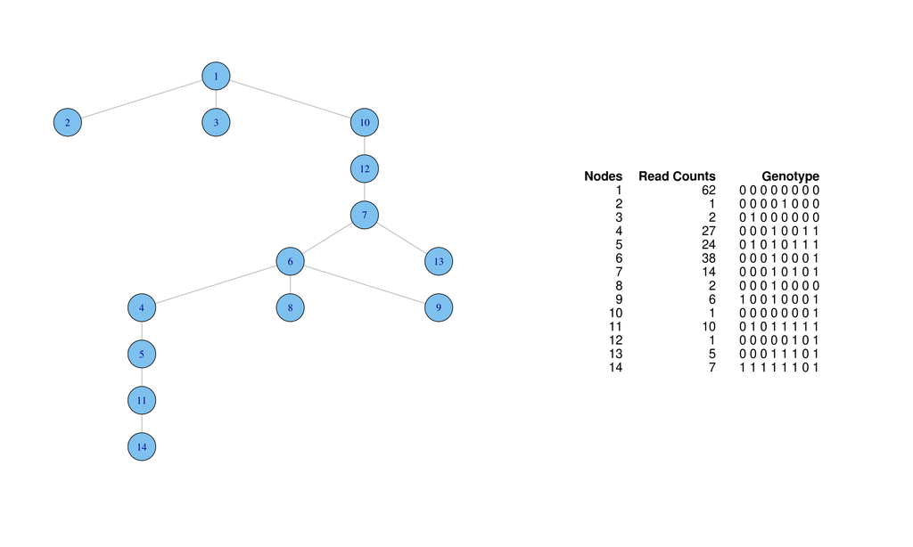

```r
mst <- get_mst(hc_genotype)
plot_mst(hc_genotype, hc_label, flag=F)
```

# 3 Reproduce figure 3B

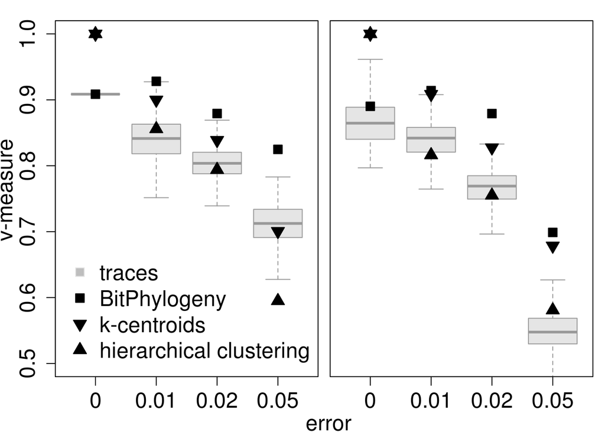

```r
data(saved_vmeasures)

mcmc_vmeasures <- saved_vmeasures$mcmc_vmeasures
hc_vmeasures <- saved_vmeasures$hc_vmeasures
kc_vmeasures <- saved_vmeasures$kc_vmeasures
mpear_vmeasures <- saved_vmeasures$mpear_vmeasures

par(mfrow=c(1,2), oma = c(3,3,0,0) + 0.1,
    mar = c(0,0,1,0.5) + 0.1, cex.lab=1.5, cex.axis=1.5)
boxplot(mcmc_vmeasures$big_clone, outline=F,
        ylim=c(0.5,1) ,
        cex.main=1.3,
        border=c('gray60'), col='gray90')
points( mpear_vmeasures$big_clone, pch=22,cex = 1.5, bg= 'black')
points( hc_vmeasures$big_clone, pch=24,cex = 1.5, bg= 'black')
points( kc_vmeasures$big_clone, pch=25,cex = 1.5, bg= 'black')

boxplot(mcmc_vmeasures$small_clone, outline=F,
        ylim=c(0.5,1) ,
        yaxt='n',cex.main=1.3,
        border=c('gray60'), col='gray90')
points( mpear_vmeasures$small_clone, pch=22, cex = 1.5, bg= 'black')
points( hc_vmeasures$small_clone, pch=24, cex=1.5, bg= 'black')
points( kc_vmeasures$small_clone, pch=25, cex = 1.5, bg= 'black')
colors1 <- c("gray90",'black', 'black', "black")
colors2 <- c("gray",'black', 'black', "black")
add_legend("bottomleft", legend=c("traces", 'BitPhylogeny',
                                  'k-centroids',
                                  'hierarchical clustering'),
           pch=c(22,22,25,24), inset = c(0.1,0.13), col=colors1,
           pt.bg=colors2,
           horiz=F, bty='n', cex=1.5)
title(xlab = "error",
      ylab = "v-measure",
      outer = TRUE, line = 2.2)
```

# 4 Reproduce figure 3C

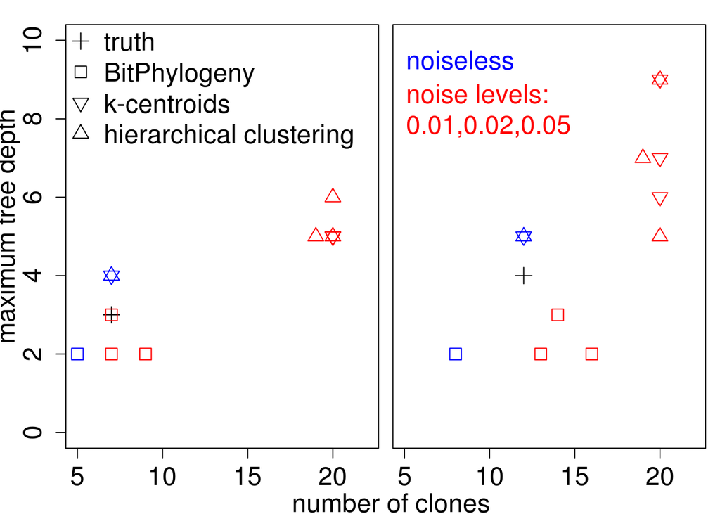

```r
big_clone_t <- c(3, 7)
big_clone_bit <- c(2, 5)
big_clone_hc <- c(4, 7)
big_clone_kc <- c(4, 7)
big_clone_bit <- rbind(big_clone_bit,
                      c(3, 7), c(2,9 ), c(2,7) )
big_clone_hc <- rbind(big_clone_hc,
                     c(5, 19), c(5,20), c(6,20))
big_clone_kc <- rbind(big_clone_kc,
                     c(5, 20), c(5, 20), c(5,20))

small_clone_t <- c(4, 12)
small_clone_bit <- c(2, 8)
small_clone_hc <- c(5, 12)
small_clone_kc <- c(5, 12)

small_clone_bit <- rbind(small_clone_bit,
                        c(3, 14),c(2,16 ), c(2,13) )
small_clone_hc <- rbind(small_clone_hc,
                       c(7, 19),c(5,20), c(9,20))
small_clone_kc <- rbind(small_clone_kc,
                       c(9, 20),c(7, 20), c(6,20))

par(mfrow=c(1,2), oma = c(3,3,0,0) + 0.1,
    mar = c(0,0,1,0.5) + 0.1, cex.lab=1.5, cex.axis=1.5)
color <- c('blue', 'red', 'red', 'red')
plot(big_clone_t[2], big_clone_t[1],pch=3, ylim=c(0,10) ,xlim= c(5,22)
     ,cex=1.5)
points(big_clone_bit[,2], big_clone_bit[,1],pch=0,cex=1.5, col=color)
points(big_clone_hc[,2], big_clone_hc[,1],pch=2,cex=1.5, col=color)
points(big_clone_kc[,2], big_clone_kc[,1],pch=6,cex=1.5, col=color)

plot(small_clone_t[2], small_clone_t[1],pch=3, ylim=c(0,10) ,xlim= c(5,22),cex=1.5,yaxt='n')
points(small_clone_bit[,2], small_clone_bit[,1],pch=0,cex=1.5, col=color)
points(small_clone_hc[,2], small_clone_hc[,1],pch=2,cex=1.5, col=color)
points(small_clone_kc[,2], small_clone_kc[,1],pch=6,cex=1.5, col=color)

colors1 <- c("black",'black', 'black', "black")
colors2 <- c("black",'black', 'black', "black")
add_legend("topleft", legend=c("truth", 'BitPhylogeny',
                                  'k-centroids',
                                  'hierarchical clustering'),
           pch=c(3,0,6,2), inset = c(0.08,0.02), col=colors1,
           pt.bg=colors2,
           horiz=F, bty='n', cex=1.5)
add_legend("topleft", legend=c("noiseless", 'noise levels: \n0.01,0.02,0.05'),
           inset = c(0.50,0.02), text.col=c('blue','red'),
           horiz=F, bty='n', cex=1.5)
title(xlab = "number of clones",
      ylab = "maximum tree depth",
      outer = TRUE, line = 2.2)
```